# Topic Model Workshop - Part 1 (LDA)

Ryan Wesslen

Nov 27, 2017

## Load the data

Let’s start by loading our packages and loading the dataset.

```r
library(quanteda); library(tidyverse); library(RColorBrewer)

dataset <- read_csv("./articles-sample.csv")

#create corpus
myCorpus <- corpus(dataset$Abstract)
```

## Create the dfm (pre-processing)

First, we need to create a dfm (document-feature matrix) and remove a standard list of English stop words.

We’ll also remove sparse terms using the `trim` function.

```r
dfm <- dfm(myCorpus,
           remove = c(stopwords("english")),
           ngrams=1L,
           stem = F,
           remove_numbers = TRUE,
           remove_punct = TRUE,
           remove_symbols = TRUE)

vdfm <- dfm_trim(dfm, min_count = 10, min_docfreq = 5)
# min_count = remove words used less than x
# min_docfreq = remove words used in less than x docs
```

Let’s explore the top 50 words.

```r
topfeatures(vdfm, n = 50)
```

```
##       study        data     results         can       using    research
##        1621        1553        1429        1305        1186        1111
##    students       model         use    analysis      health        used
##         954         953         927         891         871         832
##      social       paper        also    approach       based         may
##         825         811         754         702         696         651
## information         two        time     network     however     methods
##         651         640         627         616         614         598
##       among         new     studies      system    findings         one
##         569         567         564         562         562         542
##   different      design significant development     provide   important
##         531         520         513         507         489         484
##     support        care      method performance      within           p
##         475         469         467         466         465         465
##  associated    patients        high     factors      models     effects
##         463         450         444         439         438         437
##        well    learning
##         435         432
```

Let’s plot two word clouds: one with the raw term frequencies and one with TF-IDF.

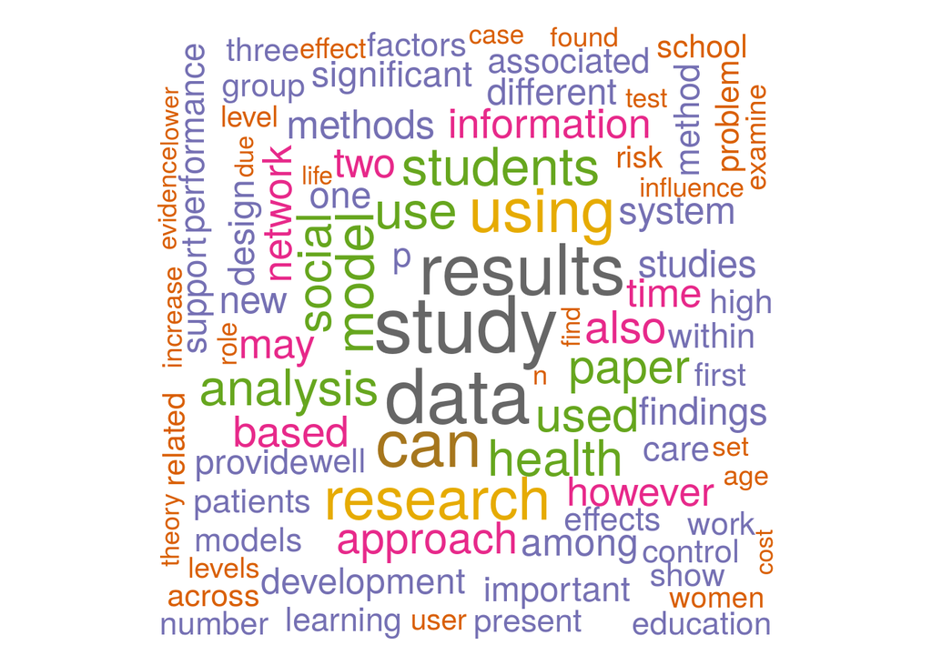

```r
textplot_wordcloud(vdfm,  scale=c(3.5, .75), colors=brewer.pal(8, "Dark2"),
     random.order = F, rot.per=0.1, max.words=250, main = "Raw Counts")
```

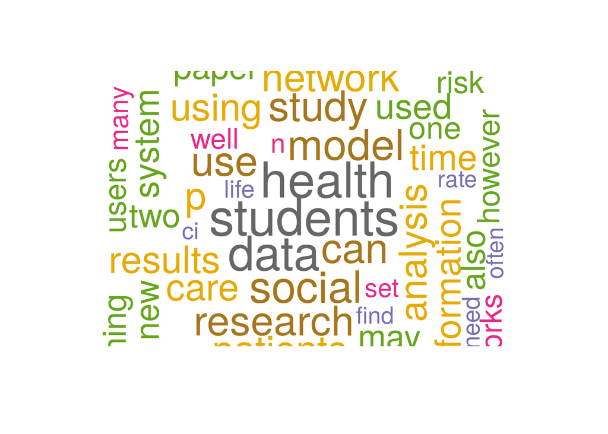

```r
textplot_wordcloud(tfidf(vdfm),  scale=c(3.5, .75), colors=brewer.pal(8, "Dark2"),
     random.order = F, rot.per=0.1, max.words=250, main = "TF-IDF")
```

Let’s now create a dendogram to get an idea of how the words are clustering.

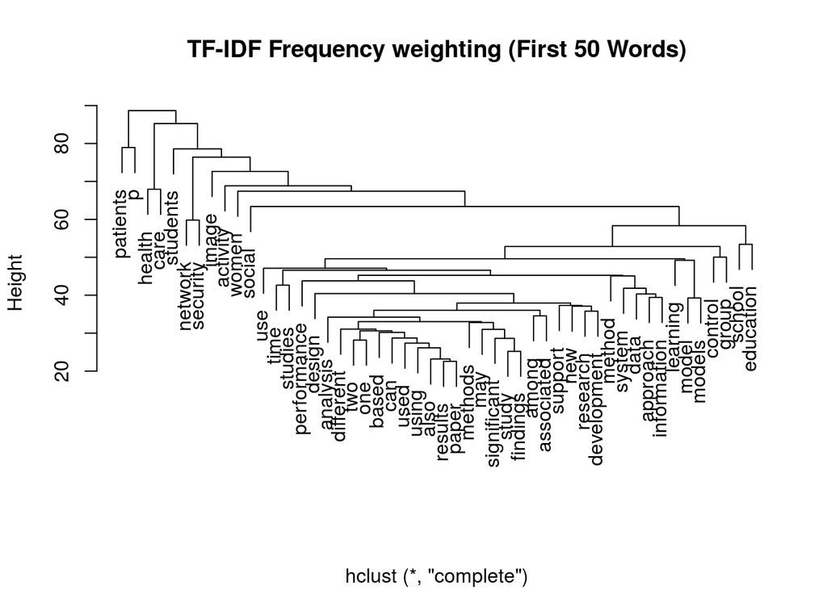

```r
numWords <- 50

wordDfm <- dfm_sort(dfm_weight(vdfm, "tfidf"))
wordDfm <- t(wordDfm)[1:numWords,]  # keep the top numWords words
wordDistMat <- dist(wordDfm)
wordCluster <- hclust(wordDistMat)
plot(wordCluster, xlab="", main="TF-IDF Frequency weighting (First 50 Words)")
```

## Topic Modeling (LDA)

For the first part, we’re going to use the `topicmodels` package to run LDA.

We’re going to run Gibbs sampling which is a simulation based approach to LDA. There are multiple parameters we need to set.

The most important parameter is the number of topics. Usually, for your first time running topic modeling, there isn’t a perfect number to start with. This is ok! Usually starting with 10 (hundred of documents) to 50 (tens of thousands of documents). Let’s start with 20.

The second important parameter is the number of iterations. We’ll set this as 500.

```r
library(topicmodels)

# we now export to a format that we can run the topic model with
dtm <- convert(vdfm, to="topicmodels")

# estimate LDA with K topics
K <- 20
lda <- LDA(dtm, k = K, method = "Gibbs",
                control = list(verbose=25L, seed = 123, burnin = 100, iter = 500))
```

```
## K = 20; V = 4468; M = 2879
## Sampling 600 iterations!
## Iteration 25 ...
## Iteration 50 ...
## Iteration 75 ...
## Iteration 100 ...
## Iteration 125 ...
## Iteration 150 ...
## Iteration 175 ...
## Iteration 200 ...
## Iteration 225 ...
## Iteration 250 ...
## Iteration 275 ...
## Iteration 300 ...
## Iteration 325 ...
## Iteration 350 ...
## Iteration 375 ...
## Iteration 400 ...
## Iteration 425 ...
## Iteration 450 ...
## Iteration 475 ...
## Iteration 500 ...
## Iteration 525 ...
## Iteration 550 ...
## Iteration 575 ...
## Iteration 600 ...
## Gibbs sampling completed!
```

## Visualizations Example: LDAVis

To explore our results, we’ll use a Shiny-based interactive visualization called LDAvis. This has been prebuilt as a R package (FYI it’s also available in Python).

In order to use it, we’ll need to convert our model results (in the `lda` object) to a json object that LDAVis requires as its input. That function is pre-loaded in the file `functions.R` within the repository.

```r
#Create Json for LDAVis
library(LDAvis)
source('./functions.R')
json <- topicmodels_json_ldavis(lda,vdfm,dtm)
new.order <- RJSONIO::fromJSON(json)$topic.order

# change open.browser = TRUE to automatically open result in browser
serVis(json, out.dir = 'unccResearch', open.browser = F)
```

Let’s view the topics.

```r
term <- terms(lda, 10)

# Topic #'s reordered!!
term <- term[,new.order]
colnames(term) <- paste("Topic",1:K)
term
```

```
##       Topic 1      Topic 2      Topic 3        Topic 4       Topic 5
##  [1,] "among"      "health"     "p"            "students"    "network"
##  [2,] "study"      "care"       "group"        "school"      "networks"
##  [3,] "women"      "patients"   "activity"     "education"   "security"
##  [4,] "use"        "patient"    "physical"     "learning"    "can"
##  [5,] "older"      "primary"    "compared"     "teachers"    "paper"
##  [6,] "associated" "cognitive"  "control"      "student"     "proposed"
##  [7,] "age"        "treatment"  "groups"       "instruction" "routing"
##  [8,] "children"   "outcomes"   "participants" "science"     "show"
##  [9,] "gender"     "included"   "ankle"        "high"        "attacks"
## [10,] "adults"     "associated" "intervention" "teacher"     "nodes"
##       Topic 6     Topic 7       Topic 8         Topic 9
##  [1,] "image"     "information" "spatial"       "relationship"
##  [2,] "images"    "users"       "land"          "findings"
##  [3,] "features"  "approach"    "change"        "research"
```

[output cut: 40 more lines]

Like topics are probability distribution of words, in LDA documents are probability distributions of topics.

First, let’s extract the document-topic probability matrix.

```r
# to get topic probabilities per document
postlist <- posterior(lda)
probtopics <- data.frame(postlist$topics)
probtopics <- probtopics[,new.order]
colnames(probtopics) <- paste("Topic",1:K)
```

Next, let’s find the most representative document for Topic 1.

```r
filter.topic <- "Topic 1"

row <- order(-probtopics[,filter.topic])[1]
dataset$Abstract[row]
```

[output not shown]